# Презентация по лабораторной работе №1

Знакомство с Cisco Packet Tracer

Лушин А.А.

Российский университет дружбы народов, Москва, Россия

Факультет Физико-математических и естественных наук

18 февраля 2005

# Информация

## Докладчик

- Лушин Артём Андреевич
- Бакалавр направления компьютерные и информационные науки
- Кафедра теории вероятности и кибербезопасности
- Российский университет дружбы народов
- lusin5745@gmail.com

# Вводная часть

## Цели и задачи

Установка инструмента моделирования конфигурации сети Cisco Packet Tracer, знакомство с его интерфейсом.

# Ход работы

## Работа с концентратором

Создаём топологию, состояющую из концентратора и 4 оконечных устройств. Выдаём адреса оконечным устройствам. Соединяем РС0 и РС2. Отправляем пакеты ARP и ICMP. Концентратор отправляем пакеты на все устройства сразу и только РС2 принимает пакет, тоже самое происходит при ответной отправке. Одновременно соединяем РС0 и РС2, а также РС2 и РС0. Создаётся коллизия, в следствии чего появляется ошибка.

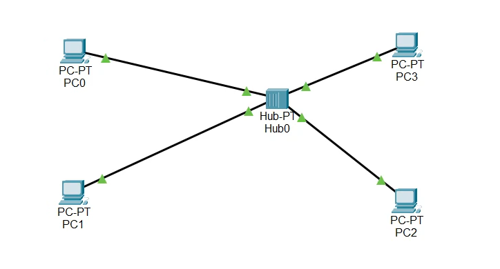

## Работа с коммутатором

Создаём топологию, состоящую из коммутатора и 4 оконечных устройств. Выдаём адреса для РС4 - РС7. Отправляем пакеты с РС4 на РС6. Сначала коммутатор также рассылает пакеты на всевозможные устройства, но потом запоминает движение до РС6 и обратно, поэтому ответный пакет сразу идёт на место назначения. Попытались создать коллизию, её не возникло, так как пакеты передаются уже по готовым направлениям.

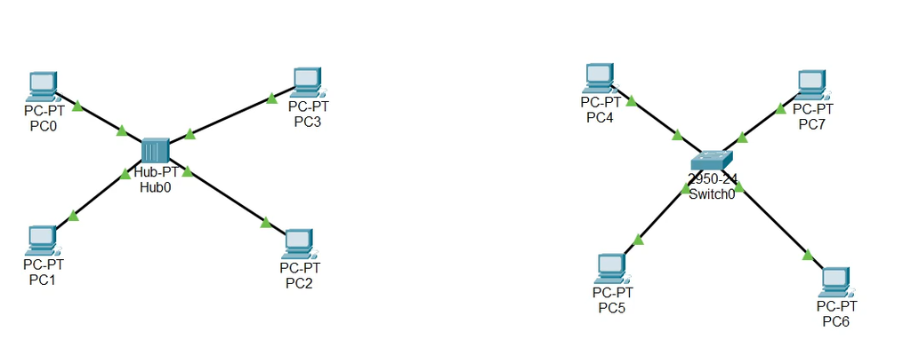

## Работа общей топологии

Отправил одновременно пакеты с РС0 на РС4 и обратно. При возникновении коллизии, пакет, шедший от концентратора удаляется и остаётся только пакет, идущий от коммутатора. Коммутатор может работать в режиме полного дуплекса. Подключили к общей топологии маршрутизатор и попробовали отправить пакеты с РС0 на маршрутизатор. Проследили за движением всех пакетов: ARP, ICMP, STP, CDP.

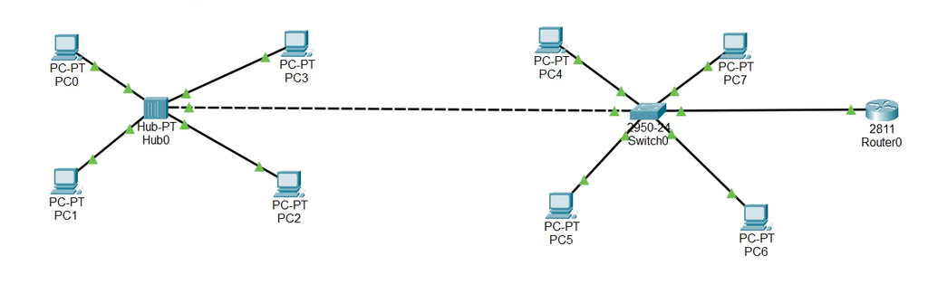

# Результаты

## Вывод

Я установил инструменты моделирования конфигурации сети Cisco Packet Tracer. Ознакомился с интерфейсом.